# Biostat 203B Homework 3

Due Feb 23 @ 11:59PM

Author

Puyuan Liu, 806152535

Load necessary libraries (you can add more as needed).

```r
library(arrow)
library(memuse)
library(pryr)
library(R.utils)
library(tidyverse)
library(ggplot2)
```

Display your machine memory.

```r
memuse::Sys.meminfo()
```

```
Totalram:  7.625 GiB
Freeram:   4.166 GiB
```

In this exercise, we use tidyverse (ggplot2, dplyr, etc) to explore the [MIMIC-IV](https://mimic.mit.edu/docs/iv/) data introduced in [homework 1](https://ucla-biostat-203b.github.io/2024winter/hw/hw1/hw1.html) and to build a cohort of ICU stays.

## Q1. Visualizing patient trajectory

Visualizing a patient’s encounters in a health care system is a common task in clinical data analysis. In this question, we will visualize a patient’s ADT (admission-discharge-transfer) history and ICU vitals in the MIMIC-IV data.

### Q1.1 ADT history

Do a similar visualization for the patient with `subject_id` 10013310 using ggplot.

Hint: We need to pull information from data files `patients.csv.gz`, `admissions.csv.gz`, `transfers.csv.gz`, `labevents.csv.gz`, `procedures_icd.csv.gz`, `diagnoses_icd.csv.gz`, `d_icd_procedures.csv.gz`, and `d_icd_diagnoses.csv.gz`. For the big file `labevents.csv.gz`, use the Parquet format you generated in Homework 2. For reproducibility, make the Parquet folder `labevents_pq` available at the current working directory `hw3`, for example, by a symbolic link. Make your code reproducible.

```r
# Extract datasets and filter useful information
patient_id <- 10013310
patients <- read_csv("~/mimic/hosp/patients.csv.gz", show_col_types = FALSE) |>
  filter(subject_id == patient_id) |>
  select(subject_id, gender, anchor_age)

admissions <- read_csv("~/mimic/hosp/admissions.csv.gz",
                       show_col_types = FALSE) |>
  filter(subject_id == patient_id) |>
  select(subject_id, race)|>
  distinct()

adt <- read_csv("~/mimic/hosp/transfers.csv.gz", show_col_types = FALSE) |>
  filter(subject_id == patient_id) |>
  select(intime, outtime, careunit)|>
  drop_na()

lab <- arrow::open_dataset("labevents_pq/part-0.parquet", format = "parquet")%>%
  dplyr::filter(subject_id == patient_id) %>%
  dplyr::select(charttime) %>%
  dplyr::distinct() %>%
  collect()

procedures_icd <- read_csv("~/mimic/hosp/procedures_icd.csv.gz",
                           show_col_types = FALSE) |>
  filter(subject_id == patient_id) |>
  select(subject_id, seq_num, icd_code, chartdate)

diagnoses_icd <- read_csv("~/mimic/hosp/diagnoses_icd.csv.gz",
                          show_col_types = FALSE) |>
  filter(subject_id == patient_id) |>
  select(subject_id, seq_num, icd_code)

d_icd_procedures <- read_csv("~/mimic/hosp/d_icd_procedures.csv.gz",
                             show_col_types = FALSE) |>
  select(icd_code, long_title)

d_icd_diagnoses <- read_csv("~/mimic/hosp/d_icd_diagnoses.csv.gz",
                            show_col_types = FALSE) |>
  select(icd_code, long_title)
```

```r
# top 3 diagnoses
top_3_diag <- left_join(diagnoses_icd, d_icd_diagnoses, by = "icd_code")|>
  select(long_title)|>
  count(long_title, sort = TRUE)|>
  slice_head(n = 3)|>
  pull(long_title)


procedure <- left_join(procedures_icd, d_icd_procedures, by = "icd_code")|>
  select(chartdate, long_title)

# patient's demographic information
patient_profile <- left_join(patients, admissions, by = "subject_id")

patient_profile
```

```
# A tibble: 1 × 4
  subject_id gender anchor_age race
       <dbl> <chr>       <dbl> <chr>
1   10013310 F              70 BLACK/AFRICAN
```

```r
# First create a blank plot with x and y axis labels
blank_plot <- ggplot() +
  labs(title = "Patient 10013310, F, 70 years old, BLACK/AFRICAN",
       subtitle = paste0(top_3_diag[1],"\n",
                         top_3_diag[2], "\n",
                         top_3_diag[3]),
       x = "Calendar time",
       y = "") +
  scale_y_discrete(limits = c("Procedure", "Lab", "ADT")) +
  theme_light()
```

```r
# Define a function to set the line width based on the care unit
line_width <- function(x) {
  4*grepl("(ICU|CCU)", x) + 2.5
}

# Plot the first layer with ADT history.
adt_plot <- blank_plot + ggtitle("Patient 10013310, F, 70 years old, black") +
  geom_segment(data = adt, aes(x = intime,
                               xend = outtime,
                               y = "ADT",
                               yend = "ADT",
                               color = careunit),
               linewidth = line_width(adt$careunit)) +
  guides(color = guide_legend(title = "Care Unit", ncol = 3, order = 1)) +
  theme(legend.position = "bottom")

# Plot the second layer with lab events.
lab_plot <- adt_plot +
  geom_point(data = lab, aes(x = charttime, y = "Lab"),
             shape = 3, size = 2.5, color = "black")
```

```r
library(stringr)

long_proc <- procedure$long_title

extract_before_comma <- function(x) {
  parts <- strsplit(x, ",")[[1]]
  return(parts[1])
}

# Apply the function to each element of the vector
procedure$long_title <- sapply(long_proc, extract_before_comma)
```

```r
full_plot <- lab_plot +
  geom_point(data = procedure, aes(x = as.POSIXct(chartdate, format="%Y-%m-%d"),
                                   y = "Procedure", shape = long_title),
             size = 4,
             color = "black") +
  guides(shape = guide_legend(title = "Procedure",
                              ncol = 2,
                              order = 2,
                              horiz = T),
         label = c("Dilation of Coronary Artery", "Long")) +
  scale_shape_manual(values = c(1:n_distinct(procedure$long_title))) +
  theme(legend.text = element_text(size = 8),
        legend.position = "bottom", legend.box = "vertical")

ggsave("10013310_adt.png", full_plot, width = 10, height = 6)
```

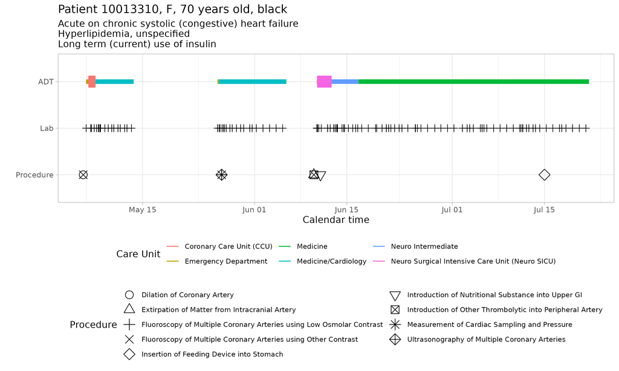

### Q1.2 ICU stays

Do a similar visualization for the patient `10013310`.

```r
# Extract the item id for vitals "HR", "NBPd", "NBPs", "RR", and "Temperature F".
patient_id <- 10013310
d_items <- read_csv("~/mimic/icu/d_items.csv.gz", show_col_types = FALSE) |>
  filter(abbreviation %in% c("HR", "NBPd", "NBPs", "RR", "Temperature F"))|>
  select(itemid, label, abbreviation)

d_items$itemid
```

```
[1] 220045 220179 220180 220210 223761
```

```bash
# Filter useful information from chartevents.csv.gz according to the item id
# and patient id
zcat < ~/mimic/icu/chartevents.csv.gz | awk -F, 'NR == 1 || ($1 == 10013310 && \
($7 == 220045 || $7 == 220180 || $7 == 220179 || $7 == 223761 || $7 == 220210))\
{print $1","$3","$5","$7","$9}' | gzip > chartevents_filtered.csv.gz
```

```r
chartevents <- read_csv("chartevents_filtered.csv.gz")
vitals <- left_join(chartevents, d_items, by = "itemid")|>
  select(subject_id, stay_id, charttime, valuenum, abbreviation)
```

```r
vital_plot <- ggplot(vitals, aes(x = charttime, y = valuenum, color = abbreviation)) +
  geom_point(size = 1.2) +
  geom_line() +
  facet_grid(rows = vars(vitals$abbreviation),
             cols = vars(vitals$stay_id),
             scales = "free") +
  labs(title = "Patient 10013310 ICU Stays - Vitals", x = "", y = "") +
  scale_x_datetime(labels = scales::date_format("%b %d %H:%M"),
                   guide = guide_axis(n.dodge = 2)) +
  theme_light() +
  theme(axis.text=element_text(size=7.5))+
  guides(color = "none")

ggsave("10013310_icu.png", vital_plot, width = 10, height = 6)
```

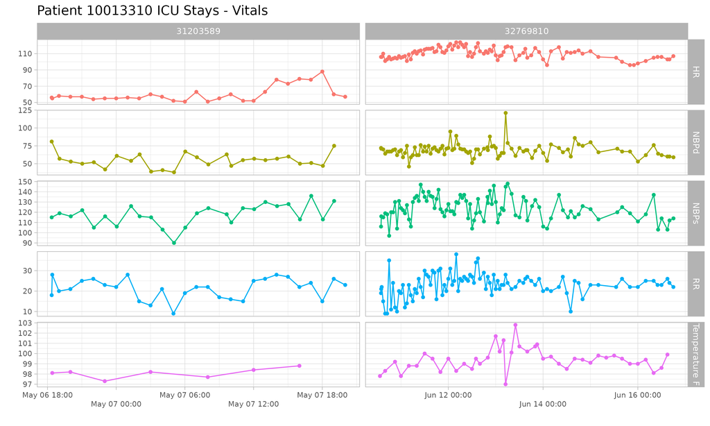

## Q2. ICU stays

`icustays.csv.gz` (https://mimic.mit.edu/docs/iv/modules/icu/icustays/) contains data about Intensive Care Units (ICU) stays. The first 10 lines are

```bash
zcat < ~/mimic/icu/icustays.csv.gz | head
```

```
subject_id,hadm_id,stay_id,first_careunit,last_careunit,intime,outtime,los
10000032,29079034,39553978,Medical Intensive Care Unit (MICU),Medical Intensive Care Unit (MICU),2180-07-23 14:00:00,2180-07-23 23:50:47,0.4102662037037037
10000980,26913865,39765666,Medical Intensive Care Unit (MICU),Medical Intensive Care Unit (MICU),2189-06-27 08:42:00,2189-06-27 20:38:27,0.4975347222222222
10001217,24597018,37067082,Surgical Intensive Care Unit (SICU),Surgical Intensive Care Unit (SICU),2157-11-20 19:18:02,2157-11-21 22:08:00,1.1180324074074075
10001217,27703517,34592300,Surgical Intensive Care Unit (SICU),Surgical Intensive Care Unit (SICU),2157-12-19 15:42:24,2157-12-20 14:27:41,0.9481134259259258
10001725,25563031,31205490,Medical/Surgical Intensive Care Unit (MICU/SICU),Medical/Surgical Intensive Care Unit (MICU/SICU),2110-04-11 15:52:22,2110-04-12 23:59:56,1.338587962962963
10001884,26184834,37510196,Medical Intensive Care Unit (MICU),Medical Intensive Care Unit (MICU),2131-01-11 04:20:05,2131-01-20 08:27:30,9.171817129629629
10002013,23581541,39060235,Cardiac Vascular Intensive Care Unit (CVICU),Cardiac Vascular Intensive Care Unit (CVICU),2160-05-18 10:00:53,2160-05-19 17:33:33,1.3143518518518518
10002155,20345487,32358465,Medical Intensive Care Unit (MICU),Medical Intensive Care Unit (MICU),2131-03-09 21:33:00,2131-03-10 18:09:21,0.8585763888888889
10002155,23822395,33685454,Coronary Care Unit (CCU),Coronary Care Unit (CCU),2129-08-04 12:45:00,2129-08-10 17:02:38,6.178912037037037
```

### Q2.1 Ingestion

Import `icustays.csv.gz` as a tibble `icustays_tble`.

**Answer:** I ingest `icustays.csv.gz` as a tibble by `read_csv`

```r
icustays_tble <- read_csv("~/mimic/icu/icustays.csv.gz",
                          show_col_types = FALSE)
```

### Q2.2 Summary and visualization

How many unique `subject_id`? Can a `subject_id` have multiple ICU stays? Summarize the number of ICU stays per `subject_id` by graphs.

```r
icustays_tble |>
  distinct(subject_id) |>
  count()
```

```
# A tibble: 1 × 1
      n
  <int>
1 50920
```

```r
nrow(icustays_tble)
```

```
[1] 73181
```

**Answer:** There are 50920 unique `subject_id` and 73181 ICU stays. Thus a `subject_id` can have multiple ICU stays. Here is a graph summarization.

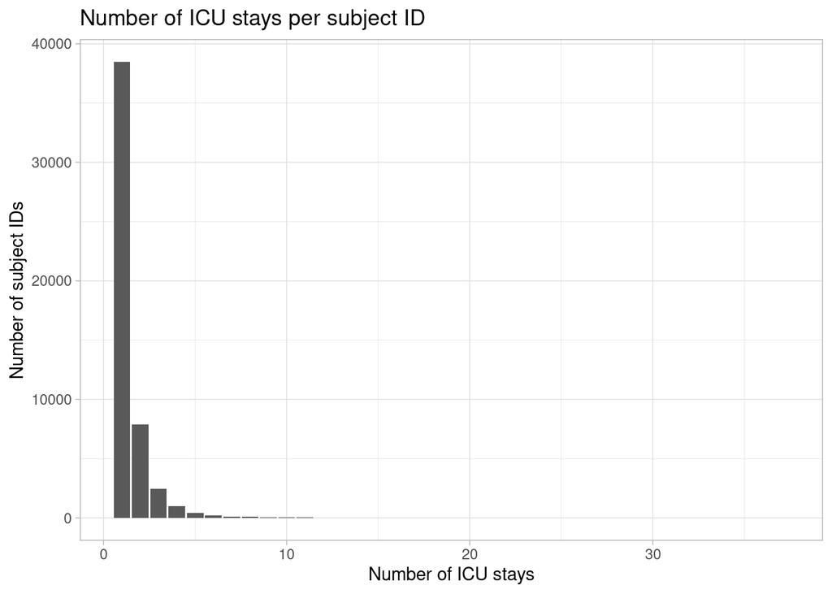

```r
icustays_tble |>
  count(subject_id) |>
  ggplot(aes(x = n)) +
  geom_bar() +
  labs(title = "Number of ICU stays per subject ID",
       x = "Number of ICU stays",
       y = "Number of subject IDs") +
  theme_light()
```

## Q3. `admissions` data

Information of the patients admitted into hospital is available in `admissions.csv.gz`. See https://mimic.mit.edu/docs/iv/modules/hosp/admissions/ for details of each field in this file. The first 10 lines are

```bash
zcat < ~/mimic/hosp/admissions.csv.gz | head
```

```
subject_id,hadm_id,admittime,dischtime,deathtime,admission_type,admit_provider_id,admission_location,discharge_location,insurance,language,marital_status,race,edregtime,edouttime,hospital_expire_flag
10000032,22595853,2180-05-06 22:23:00,2180-05-07 17:15:00,,URGENT,P874LG,TRANSFER FROM HOSPITAL,HOME,Other,ENGLISH,WIDOWED,WHITE,2180-05-06 19:17:00,2180-05-06 23:30:00,0
10000032,22841357,2180-06-26 18:27:00,2180-06-27 18:49:00,,EW EMER.,P09Q6Y,EMERGENCY ROOM,HOME,Medicaid,ENGLISH,WIDOWED,WHITE,2180-06-26 15:54:00,2180-06-26 21:31:00,0
10000032,25742920,2180-08-05 23:44:00,2180-08-07 17:50:00,,EW EMER.,P60CC5,EMERGENCY ROOM,HOSPICE,Medicaid,ENGLISH,WIDOWED,WHITE,2180-08-05 20:58:00,2180-08-06 01:44:00,0
10000032,29079034,2180-07-23 12:35:00,2180-07-25 17:55:00,,EW EMER.,P30KEH,EMERGENCY ROOM,HOME,Medicaid,ENGLISH,WIDOWED,WHITE,2180-07-23 05:54:00,2180-07-23 14:00:00,0
10000068,25022803,2160-03-03 23:16:00,2160-03-04 06:26:00,,EU OBSERVATION,P51VDL,EMERGENCY ROOM,,Other,ENGLISH,SINGLE,WHITE,2160-03-03 21:55:00,2160-03-04 06:26:00,0
10000084,23052089,2160-11-21 01:56:00,2160-11-25 14:52:00,,EW EMER.,P6957U,WALK-IN/SELF REFERRAL,HOME HEALTH CARE,Medicare,ENGLISH,MARRIED,WHITE,2160-11-20 20:36:00,2160-11-21 03:20:00,0
10000084,29888819,2160-12-28 05:11:00,2160-12-28 16:07:00,,EU OBSERVATION,P63AD6,PHYSICIAN REFERRAL,,Medicare,ENGLISH,MARRIED,WHITE,2160-12-27 18:32:00,2160-12-28 16:07:00,0
10000108,27250926,2163-09-27 23:17:00,2163-09-28 09:04:00,,EU OBSERVATION,P38XXV,EMERGENCY ROOM,,Other,ENGLISH,SINGLE,WHITE,2163-09-27 16:18:00,2163-09-28 09:04:00,0
10000117,22927623,2181-11-15 02:05:00,2181-11-15 14:52:00,,EU OBSERVATION,P2358X,EMERGENCY ROOM,,Other,ENGLISH,DIVORCED,WHITE,2181-11-14 21:51:00,2181-11-15 09:57:00,0
```

### Q3.1 Ingestion

Import `admissions.csv.gz` as a tibble `admissions_tble`.

**Answer:** I ingest `admissions.csv.gz` as a tibble by `read_csv`

```r
admissions_tble <- read_csv("~/mimic/hosp/admissions.csv.gz",
                            show_col_types = FALSE)
```

### Q3.2 Summary and visualization

Summarize the following information by graphics and explain any patterns you see.

- number of admissions per patient
- admission hour (anything unusual?)
- admission minute (anything unusual?)
- length of hospital stay (from admission to discharge) (anything unusual?)

According to the [MIMIC-IV documentation](https://mimic.mit.edu/docs/iv/about/concepts/#date-shifting),

> All dates in the database have been shifted to protect patient confidentiality. Dates will be internally consistent for the same patient, but randomly distributed in the future. Dates of birth which occur in the present time are not true dates of birth. Furthermore, dates of birth which occur before the year 1900 occur if the patient is older than 89. In these cases, the patient’s age at their first admission has been fixed to 300.

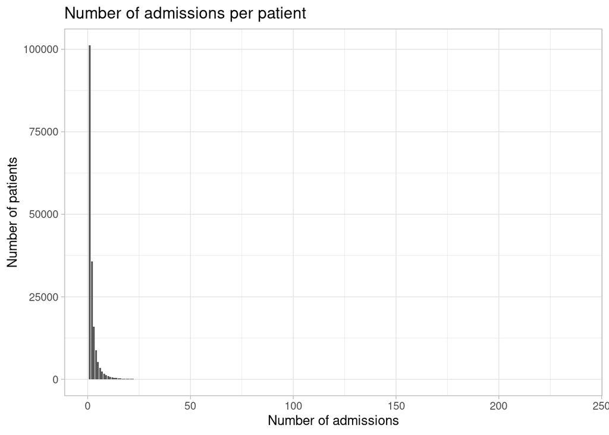

```r
admissions_tble |>
  count(subject_id) |>
  ggplot(aes(x = n)) +
  geom_bar() +
  labs(title = "Number of admissions per patient",
       x = "Number of admissions",
       y = "Number of patients") +
  theme_light()
```

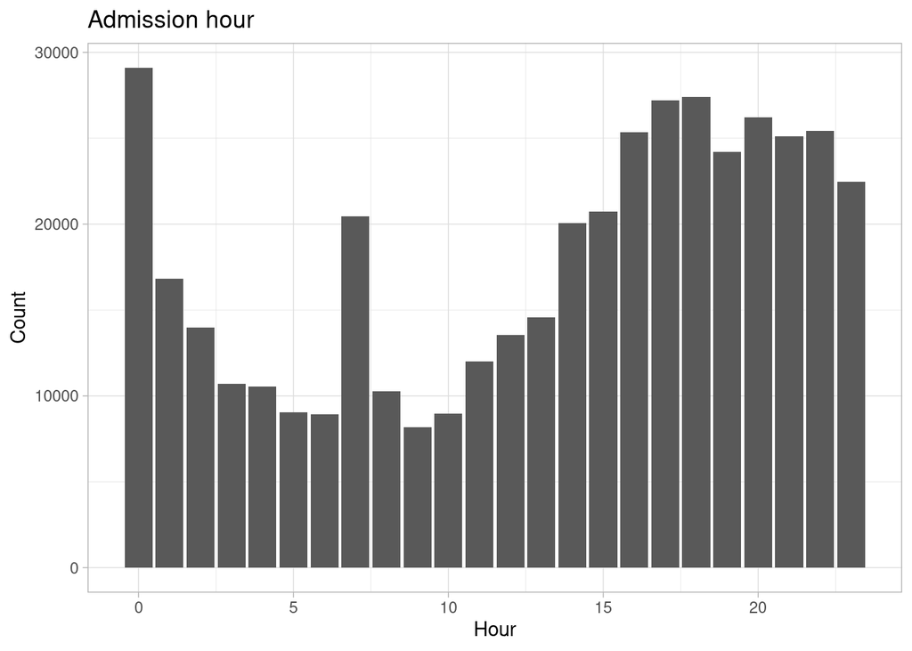

```r
admissions_tble |>
  ggplot(aes(x = hour(admittime))) +
  geom_bar() +
  labs(title = "Admission hour",
       x = "Hour",
       y = "Count") +
  theme_light()
```

**Answer:** The admission hours on 0AM, 7AM., and 2PM until the midnight have higher frequency than other hours. It might be due to the shift change of the hospital staffs.

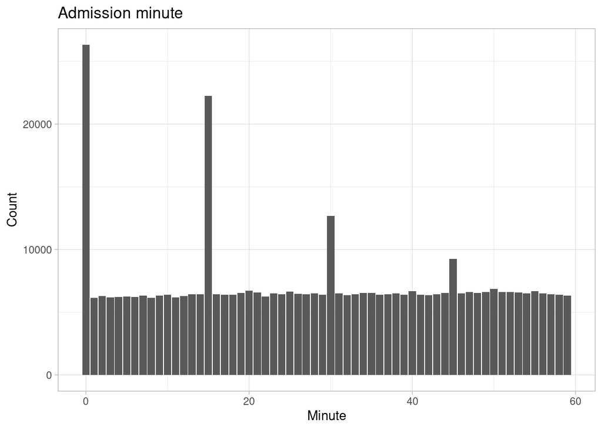

```r
admissions_tble |>
  ggplot(aes(x = minute(admittime))) +
  geom_bar() +
  labs(title = "Admission minute",
       x = "Minute",
       y = "Count") +
  theme_light()
```

**Answer:** The admission minutes are not uniformly distributed overall. The frequency of 0, 15, 30, and 45 minutes are much higher than other minutes. While other minutes are approximately uniformly distributed. It might be due to the rounding of the admission time.

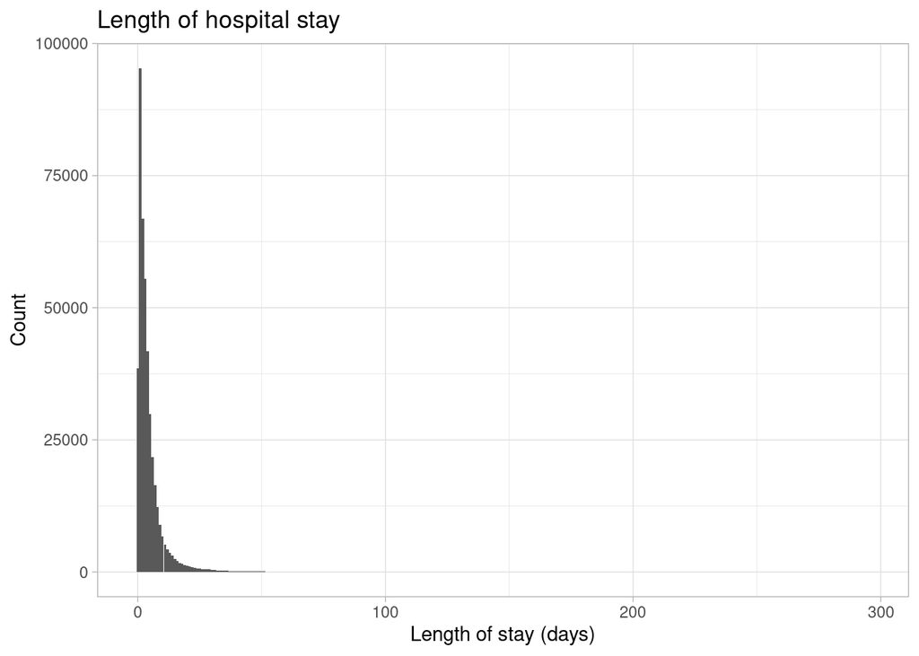

```r
admissions_tble |>
  mutate(los = as.numeric(difftime(dischtime, admittime, units = "days"))) |>
  ggplot(aes(x = los)) +
  geom_histogram(binwidth = 1) +
  labs(title = "Length of hospital stay",
       x = "Length of stay (days)",
       y = "Count") +
  theme_light()
```

**Answer:** The length of hospital stay is right-skewed. Most of the patients stay in the hospital for less than 10 days. There are some patients stay in the hospital for more than 100 days. It might be due to the patients with chronic diseases or severe conditions.

## Q4. `patients` data

Patient information is available in `patients.csv.gz`. See https://mimic.mit.edu/docs/iv/modules/hosp/patients/ for details of each field in this file. The first 10 lines are

```bash
zcat < ~/mimic/hosp/patients.csv.gz | head
```

```
subject_id,gender,anchor_age,anchor_year,anchor_year_group,dod
10000032,F,52,2180,2014 - 2016,2180-09-09
10000048,F,23,2126,2008 - 2010,
10000068,F,19,2160,2008 - 2010,
10000084,M,72,2160,2017 - 2019,2161-02-13
10000102,F,27,2136,2008 - 2010,
10000108,M,25,2163,2014 - 2016,
10000115,M,24,2154,2017 - 2019,
10000117,F,48,2174,2008 - 2010,
10000178,F,59,2157,2017 - 2019,
```

### Q4.1 Ingestion

Import `patients.csv.gz` (https://mimic.mit.edu/docs/iv/modules/hosp/patients/) as a tibble `patients_tble`.

**Answer:** I ingest `patients.csv.gz` as a tibble by `read_csv`

```r
patients_tble <- read_csv("~/mimic/hosp/patients.csv.gz",
                          show_col_types = FALSE)
```

### Q4.2 Summary and visualization

Summarize variables `gender` and `anchor_age` by graphics, and explain any patterns you see.

```r
count(patients_tble, gender)
```

```
# A tibble: 2 × 2
  gender      n
  <chr>   <int>
1 F      158553
2 M      141159
```

```r
range(patients_tble$anchor_age)
```

```
[1] 18 91
```

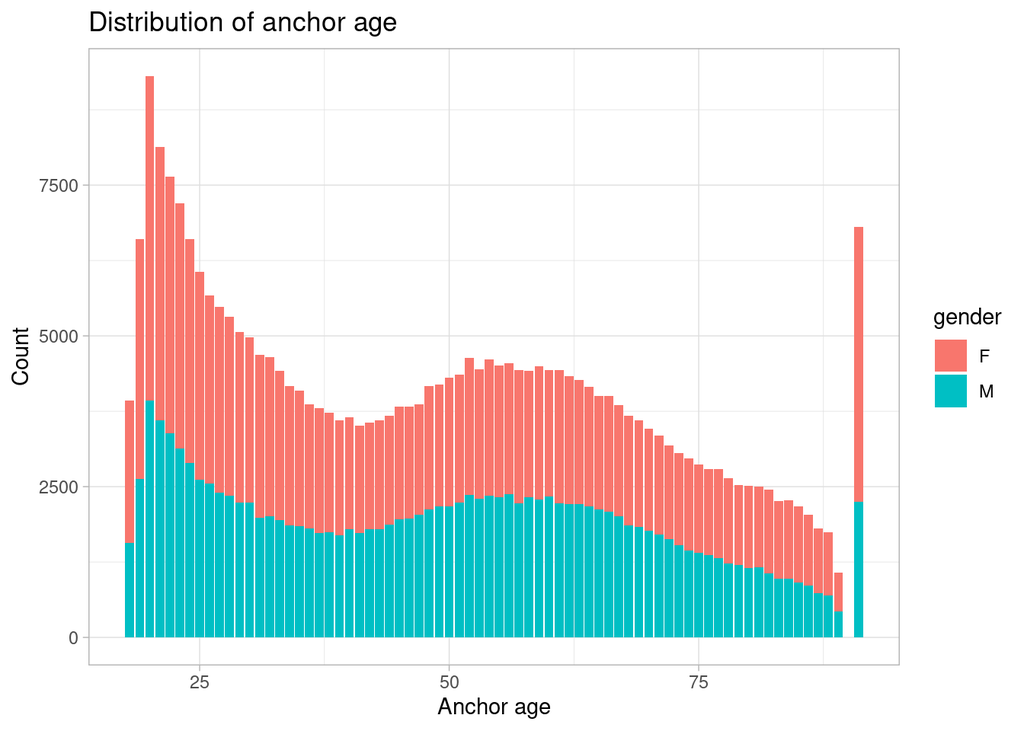

```r
patients_tble|>
  ggplot(aes(x = anchor_age, fill = gender)) +
  geom_bar() +
  labs(title = "Distribution of anchor age",
       x = "Anchor age",
       y = "Count") +
  theme_light()
```

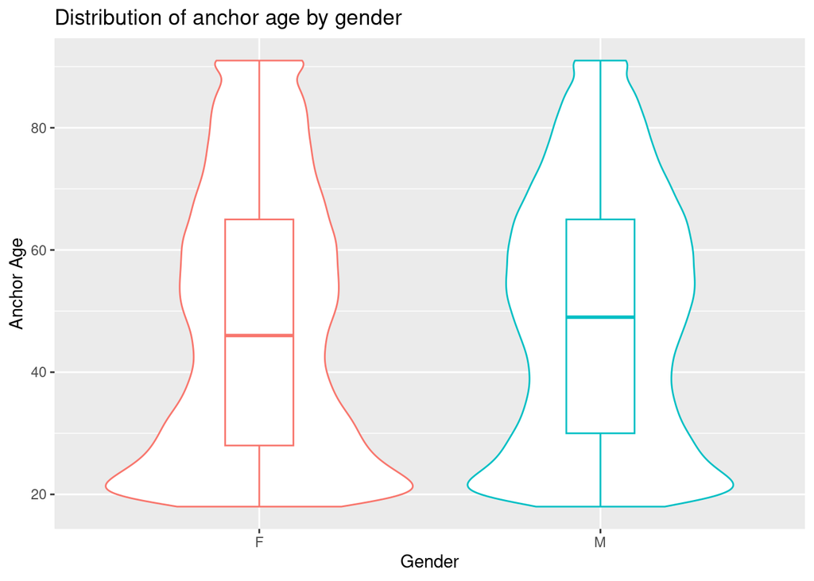

```r
patients_tble|>
  ggplot(aes(x = gender, y = anchor_age, color=gender)) +
  geom_violin() +
  geom_boxplot(width = 0.2) +
  labs(title = "Distribution of anchor age by gender",
       x = "Gender",
       y = "Anchor Age") +
  guides(color = "none")
```

**Answer:**

- I ploted a bar plot and a violin plot to show the distribution of anchor age by gender.
- The number of females is slightly higher than the number of males.
- There are more patients with anchor age 19 to 30 and age 91 than other ages.
- Compared with females, males have a higher proportion of patients with anchor age around 50 to 65, and lower proportion of patients with achor age less than 30.

## Q5. Lab results

`labevents.csv.gz` (https://mimic.mit.edu/docs/iv/modules/hosp/labevents/) contains all laboratory measurements for patients. The first 10 lines are

```bash
zcat < ~/mimic/hosp/labevents.csv.gz | head
```

```
labevent_id,subject_id,hadm_id,specimen_id,itemid,order_provider_id,charttime,storetime,value,valuenum,valueuom,ref_range_lower,ref_range_upper,flag,priority,comments
1,10000032,,45421181,51237,P28Z0X,2180-03-23 11:51:00,2180-03-23 15:15:00,1.4,1.4,,0.9,1.1,abnormal,ROUTINE,
2,10000032,,45421181,51274,P28Z0X,2180-03-23 11:51:00,2180-03-23 15:15:00,___,15.1,sec,9.4,12.5,abnormal,ROUTINE,VERIFIED.
3,10000032,,52958335,50853,P28Z0X,2180-03-23 11:51:00,2180-03-25 11:06:00,___,15,ng/mL,30,60,abnormal,ROUTINE,NEW ASSAY IN USE ___: DETECTS D2 AND D3 25-OH ACCURATELY.
4,10000032,,52958335,50861,P28Z0X,2180-03-23 11:51:00,2180-03-23 16:40:00,102,102,IU/L,0,40,abnormal,ROUTINE,
5,10000032,,52958335,50862,P28Z0X,2180-03-23 11:51:00,2180-03-23 16:40:00,3.3,3.3,g/dL,3.5,5.2,abnormal,ROUTINE,
6,10000032,,52958335,50863,P28Z0X,2180-03-23 11:51:00,2180-03-23 16:40:00,109,109,IU/L,35,105,abnormal,ROUTINE,
7,10000032,,52958335,50864,P28Z0X,2180-03-23 11:51:00,2180-03-23 16:40:00,___,8,ng/mL,0,8.7,,ROUTINE,MEASURED BY ___.
8,10000032,,52958335,50868,P28Z0X,2180-03-23 11:51:00,2180-03-23 16:40:00,12,12,mEq/L,8,20,,ROUTINE,
9,10000032,,52958335,50878,P28Z0X,2180-03-23 11:51:00,2180-03-23 16:40:00,143,143,IU/L,0,40,abnormal,ROUTINE,
```

`d_labitems.csv.gz` (https://mimic.mit.edu/docs/iv/modules/hosp/d_labitems/) is the dictionary of lab measurements.

```bash
zcat < ~/mimic/hosp/d_labitems.csv.gz | head
```

```
itemid,label,fluid,category
50801,Alveolar-arterial Gradient,Blood,Blood Gas
50802,Base Excess,Blood,Blood Gas
50803,"Calculated Bicarbonate, Whole Blood",Blood,Blood Gas
50804,Calculated Total CO2,Blood,Blood Gas
50805,Carboxyhemoglobin,Blood,Blood Gas
50806,"Chloride, Whole Blood",Blood,Blood Gas
50808,Free Calcium,Blood,Blood Gas
50809,Glucose,Blood,Blood Gas
50810,"Hematocrit, Calculated",Blood,Blood Gas
```

We are interested in the lab measurements of creatinine (50912), potassium (50971), sodium (50983), chloride (50902), bicarbonate (50882), hematocrit (51221), white blood cell count (51301), and glucose (50931). Retrieve a subset of `labevents.csv.gz` that only containing these items for the patients in `icustays_tble`. Further restrict to the last available measurement (by `storetime`) before the ICU stay. The final `labevents_tble` should have one row per ICU stay and columns for each lab measurement.

Hint: Use the Parquet format you generated in Homework 2. For reproducibility, make `labevents_pq` folder available at the current working directory `hw3`, for example, by a symbolic link.

```r
subset_lab <- c("50912", "50971", "50983", "50902",
                "50882", "51221", "51301", "50931")

d_labitems_tble <- read_csv("~/mimic/hosp/d_labitems.csv.gz",
                            show_col_types = FALSE) |>
  filter(itemid %in% subset_lab) |>
  print(width = Inf)
```

```
# A tibble: 8 × 4
  itemid label             fluid category
   <dbl> <chr>             <chr> <chr>
1  50882 Bicarbonate       Blood Chemistry
2  50902 Chloride          Blood Chemistry
3  50912 Creatinine        Blood Chemistry
4  50931 Glucose           Blood Chemistry
5  50971 Potassium         Blood Chemistry
6  50983 Sodium            Blood Chemistry
7  51221 Hematocrit        Blood Hematology
8  51301 White Blood Cells Blood Hematology
```

```r
labevents <- arrow::open_dataset("labevents_pq/part-0.parquet",
                                 format = "parquet")%>%
  dplyr::filter(itemid %in% subset_lab) %>%
  dplyr::filter(subject_id %in% icustays_tble$subject_id) %>%
  dplyr::select(subject_id, itemid, storetime, valuenum) %>%
  collect()
```

```r
if (file.exists("labevents_tble.rds")) {
  labevents_tble <- read_rds("labevents_tble.rds")
  labevents_tble
} else {
  labevents_tble <- labevents |>
    left_join(
      select(icustays_tble, subject_id, stay_id, intime),
      by = "subject_id"
      ) |>
    # filter the last available measurement before the ICU stay
    filter(storetime < intime) |>
    # group by subject_id, stay_id, itemid
    group_by(subject_id, stay_id, itemid) |>
    # pick the last available measurement before the ICU stay
    arrange(storetime, by_group = TRUE) |>
    slice_tail(n = 1) |>
    select(-intime, -storetime) |>
    pivot_wider(names_from = itemid, values_from = valuenum) |>
    rename_with(~d_labitems_tble$label[d_labitems_tble$itemid == .x],
                .cols = -c(subject_id, stay_id)) |>
    print(width = Inf)|>
    write_rds("labevents_tble.rds")
}
```

```
# A tibble: 68,467 × 10
# Groups:   subject_id, stay_id [68,467]
   subject_id  stay_id Bicarbonate Chloride Creatinine Glucose Potassium Sodium
        <dbl>    <dbl>       <dbl>    <dbl>      <dbl>   <dbl>     <dbl>  <dbl>
 1   10000032 39553978          25       95        0.7     102       6.7    126
 2   10000980 39765666          21      109        2.3      89       3.9    144
 3   10001217 34592300          30      104        0.5      87       4.1    142
 4   10001217 37067082          22      108        0.6     112       4.2    142
 5   10001725 31205490          NA       98       NA        NA       4.1    139
 6   10001884 37510196          30       88        1.1     141       4.5    130
 7   10002013 39060235          24      102        0.9     288       3.5    137
 8   10002155 31090461          23       98        2.8     117       4.9    135
 9   10002155 32358465          26       85        1.4     133       5.7    120
10   10002155 33685454          24      105        1.1     138       4.6    139
# ℹ 68,457 more rows
# ℹ 2 more variables: Hematocrit <dbl>, `White Blood Cells` <dbl>
```

## Q6. Vitals from charted events

`chartevents.csv.gz` (https://mimic.mit.edu/docs/iv/modules/icu/chartevents/) contains all the charted data available for a patient. During their ICU stay, the primary repository of a patient’s information is their electronic chart. The `itemid` variable indicates a single measurement type in the database. The `value` variable is the value measured for `itemid`. The first 10 lines of `chartevents.csv.gz` are

```bash
zcat < ~/mimic/icu/chartevents.csv.gz | head
```

```
subject_id,hadm_id,stay_id,caregiver_id,charttime,storetime,itemid,value,valuenum,valueuom,warning
10000032,29079034,39553978,47007,2180-07-23 21:01:00,2180-07-23 22:15:00,220179,82,82,mmHg,0
10000032,29079034,39553978,47007,2180-07-23 21:01:00,2180-07-23 22:15:00,220180,59,59,mmHg,0
10000032,29079034,39553978,47007,2180-07-23 21:01:00,2180-07-23 22:15:00,220181,63,63,mmHg,0
10000032,29079034,39553978,47007,2180-07-23 22:00:00,2180-07-23 22:15:00,220045,94,94,bpm,0
10000032,29079034,39553978,47007,2180-07-23 22:00:00,2180-07-23 22:15:00,220179,85,85,mmHg,0
10000032,29079034,39553978,47007,2180-07-23 22:00:00,2180-07-23 22:15:00,220180,55,55,mmHg,0
10000032,29079034,39553978,47007,2180-07-23 22:00:00,2180-07-23 22:15:00,220181,62,62,mmHg,0
10000032,29079034,39553978,47007,2180-07-23 22:00:00,2180-07-23 22:15:00,220210,20,20,insp/min,0
10000032,29079034,39553978,47007,2180-07-23 22:00:00,2180-07-23 22:15:00,220277,95,95,%,0
```

`d_items.csv.gz` (https://mimic.mit.edu/docs/iv/modules/icu/d_items/) is the dictionary for the `itemid` in `chartevents.csv.gz`.

```bash
zcat < ~/mimic/icu/d_items.csv.gz | head
```

```
itemid,label,abbreviation,linksto,category,unitname,param_type,lownormalvalue,highnormalvalue
220001,Problem List,Problem List,chartevents,General,,Text,,
220003,ICU Admission date,ICU Admission date,datetimeevents,ADT,,Date and time,,
220045,Heart Rate,HR,chartevents,Routine Vital Signs,bpm,Numeric,,
220046,Heart rate Alarm - High,HR Alarm - High,chartevents,Alarms,bpm,Numeric,,
220047,Heart Rate Alarm - Low,HR Alarm - Low,chartevents,Alarms,bpm,Numeric,,
220048,Heart Rhythm,Heart Rhythm,chartevents,Routine Vital Signs,,Text,,
220050,Arterial Blood Pressure systolic,ABPs,chartevents,Routine Vital Signs,mmHg,Numeric,90,140
220051,Arterial Blood Pressure diastolic,ABPd,chartevents,Routine Vital Signs,mmHg,Numeric,60,90
220052,Arterial Blood Pressure mean,ABPm,chartevents,Routine Vital Signs,mmHg,Numeric,,
```

We are interested in the vitals for ICU patients: heart rate (220045), systolic non-invasive blood pressure (220179), diastolic non-invasive blood pressure (220180), body temperature in Fahrenheit (223761), and respiratory rate (220210). Retrieve a subset of `chartevents.csv.gz` only containing these items for the patients in `icustays_tble`. Further restrict to the first vital measurement within the ICU stay. The final `chartevents_tble` should have one row per ICU stay and columns for each vital measurement.

Hint: Use the Parquet format you generated in Homework 2. For reproducibility, make `chartevents_pq` folder available at the current working directory, for example, by a symbolic link.

**Answer:**

- First I read the d_items.csv.gz and filter the useful information according to the item id.

```r
subset_vital <- c("220045", "220179", "220180", "223761", "220210")

d_items_tble <- read_csv("~/mimic/icu/d_items.csv.gz",
                         show_col_types = FALSE) |>
  filter(itemid %in% subset_vital) |>
  print(width = Inf)
```

```
# A tibble: 5 × 9
  itemid label                                 abbreviation  linksto
   <dbl> <chr>                                 <chr>         <chr>
1 220045 Heart Rate                            HR            chartevents
2 220179 Non Invasive Blood Pressure systolic  NBPs          chartevents
3 220180 Non Invasive Blood Pressure diastolic NBPd          chartevents
4 220210 Respiratory Rate                      RR            chartevents
5 223761 Temperature Fahrenheit                Temperature F chartevents
  category            unitname param_type lownormalvalue highnormalvalue
  <chr>               <chr>    <chr>               <dbl>           <dbl>
1 Routine Vital Signs bpm      Numeric                NA              NA
2 Routine Vital Signs mmHg     Numeric                NA              NA
3 Routine Vital Signs mmHg     Numeric                NA              NA
4 Respiratory         insp/min Numeric                NA              NA
5 Routine Vital Signs °F       Numeric                NA              NA
```

```r
chart <- arrow::open_dataset("chartevents_pq/part-0.parquet",
                             format = "parquet")%>%
  dplyr::filter(subject_id %in% icustays_tble$subject_id) %>%
  dplyr::filter(itemid %in% subset_vital) %>%
  dplyr::select(subject_id, itemid, charttime, valuenum) %>%
  collect() %>%
  print(width = Inf)
```

```
# A tibble: 22,504,119 × 4
   subject_id itemid charttime           valuenum
        <int>  <int> <dttm>                 <dbl>
 1   10000032 220179 2180-07-23 14:01:00       82
 2   10000032 220180 2180-07-23 14:01:00       59
 3   10000032 220045 2180-07-23 15:00:00       94
 4   10000032 220179 2180-07-23 15:00:00       85
 5   10000032 220180 2180-07-23 15:00:00       55
 6   10000032 220210 2180-07-23 15:00:00       20
 7   10000032 220045 2180-07-23 12:00:00       97
 8   10000032 220179 2180-07-23 12:00:00       93
 9   10000032 220180 2180-07-23 12:00:00       41
10   10000032 220210 2180-07-23 12:00:00       16
# ℹ 22,504,109 more rows
```

```r
if (file.exists("chartevents_tble.rds")) {
  chartevents_tble <- read_rds("chartevents_tble.rds")|>
  print(width = Inf)
} else {
  chartevents_tble <- chart |>
    left_join(
      select(icustays_tble, subject_id, stay_id, intime, outtime),
      by = "subject_id"
      ) |>
    # filter the first vital measurement during the ICU stay
    filter(charttime >= intime) |>
    filter(charttime <= outtime) |>
    # group by subject_id, stay_id, itemid
    group_by(subject_id, stay_id, itemid) |>
    # pick the first vital measurement during the ICU stay
    arrange(charttime, by_group = TRUE) |>
    slice_head(n = 1) |>
    select(-intime, -charttime, -outtime) |>
    pivot_wider(names_from = itemid, values_from = valuenum) |>
    rename_with(~d_items_tble$label[d_items_tble$itemid == .x],
                .cols = -c(subject_id, stay_id)) |>
    print(width = Inf)|>
    write_rds("chartevents_tble.rds")
}
```

```
# A tibble: 73,164 × 7
# Groups:   subject_id, stay_id [73,164]
   subject_id  stay_id `Heart Rate` `Non Invasive Blood Pressure systolic`
        <dbl>    <dbl>        <dbl>                                  <dbl>
 1   10000032 39553978           91                                     84
 2   10000980 39765666           77                                    150
 3   10001217 34592300           96                                    167
 4   10001217 37067082           86                                    151
 5   10001725 31205490           55                                     73
 6   10001884 37510196           38                                    180
 7   10002013 39060235           80                                    104
 8   10002155 31090461           94                                    118
 9   10002155 32358465           98                                    109
10   10002155 33685454           68                                    126
   `Non Invasive Blood Pressure diastolic` `Respiratory Rate`
```

[output cut: 24 more lines]

## Q7. Putting things together

Let us create a tibble `mimic_icu_cohort` for all ICU stays, where rows are all ICU stays of adults (age at `intime` >= 18) and columns contain at least following variables

- all variables in `icustays_tble`
- all variables in `admissions_tble`
- all variables in `patients_tble`
- the last lab measurements before the ICU stay in `labevents_tble`
- the first vital measurements during the ICU stay in `chartevents_tble`

The final `mimic_icu_cohort` should have one row per ICU stay and columns for each variable.

```r
# Gather all the information together by left join
if (file.exists("mimic_icu_cohort.rds")) {
  mimic_icu_cohort <- read_rds("mimic_icu_cohort.rds")|>
  print(width = Inf)
} else {
  mimic_icu_cohort <- icustays_tble |>
    left_join(admissions_tble, by = c("subject_id", "hadm_id")) |>
    left_join(patients_tble, by = "subject_id") |>
    left_join(labevents_tble, by = c("subject_id", "stay_id")) |>
    left_join(chartevents_tble, by = c("subject_id", "stay_id")) |>
    mutate(age = anchor_age + year(intime) - anchor_year) %>%
    # filter patients with aged >= 18 at ·intime·
    filter(age >= 18) %>%
    print(width = Inf) |>
    write_rds("mimic_icu_cohort.rds")
}
```

```
# A tibble: 73,181 × 41
   subject_id  hadm_id  stay_id first_careunit
        <dbl>    <dbl>    <dbl> <chr>
 1   10000032 29079034 39553978 Medical Intensive Care Unit (MICU)
 2   10000980 26913865 39765666 Medical Intensive Care Unit (MICU)
 3   10001217 24597018 37067082 Surgical Intensive Care Unit (SICU)
 4   10001217 27703517 34592300 Surgical Intensive Care Unit (SICU)
 5   10001725 25563031 31205490 Medical/Surgical Intensive Care Unit (MICU/SICU)
 6   10001884 26184834 37510196 Medical Intensive Care Unit (MICU)
 7   10002013 23581541 39060235 Cardiac Vascular Intensive Care Unit (CVICU)
 8   10002155 20345487 32358465 Medical Intensive Care Unit (MICU)
 9   10002155 23822395 33685454 Coronary Care Unit (CCU)
10   10002155 28994087 31090461 Medical/Surgical Intensive Care Unit (MICU/SICU)
   last_careunit                                    intime
   <chr>                                            <dttm>
```

[output cut: 131 more lines]

## Q8. Exploratory data analysis (EDA)

Summarize the following information about the ICU stay cohort `mimic_icu_cohort` using appropriate numerics or graphs:

- Length of ICU stay `los` vs demographic variables (race, insurance, marital_status, gender, age at intime)
- Length of ICU stay `los` vs race

```r
# Numerical summary of length of ICU stay by race
race_summary <- mimic_icu_cohort %>%
  group_by(race) %>%
  summarize(
    mean_los_race = mean(los, na.rm = TRUE),
    median_los_race = median(los, na.rm = TRUE),
    min_los_race = min(los, na.rm = TRUE),
    max_los_race = max(los, na.rm = TRUE),
    sd_los_race = sd(los, na.rm = TRUE),
    count = n()
  )
print(race_summary, width = Inf)
```

```
# A tibble: 33 × 7
   race                          mean_los_race median_los_race min_los_race
   <chr>                                 <dbl>           <dbl>        <dbl>
 1 AMERICAN INDIAN/ALASKA NATIVE          4.46            2.09      0.0879
 2 ASIAN                                  3.49            1.93      0.0631
 3 ASIAN - ASIAN INDIAN                   4.20            1.95      0.160
 4 ASIAN - CHINESE                        3.36            1.86      0.0206
 5 ASIAN - KOREAN                         4.23            2.08      0.211
 6 ASIAN - SOUTH EAST ASIAN               3.04            1.82      0.0784
 7 BLACK/AFRICAN                          3.82            2.02      0.0345
 8 BLACK/AFRICAN AMERICAN                 3.28            1.85      0.00346
 9 BLACK/CAPE VERDEAN                     3.22            1.70      0.0296
10 BLACK/CARIBBEAN ISLAND                 3.61            1.95      0.0445
   max_los_race sd_los_race count
          <dbl>       <dbl> <int>
 1         49.9        6.54   140
 2         59.5        4.90   840
 3         66.3        7.61   179
 4         77.7        5.39   792
 5         39.4        6.35    51
 6         76.1        5.42   293
 7         54.8        5.90   309
 8         95.8        4.80  6723
 9         51.7        4.94   502
10         38.2        5.13   426
# ℹ 23 more rows
```

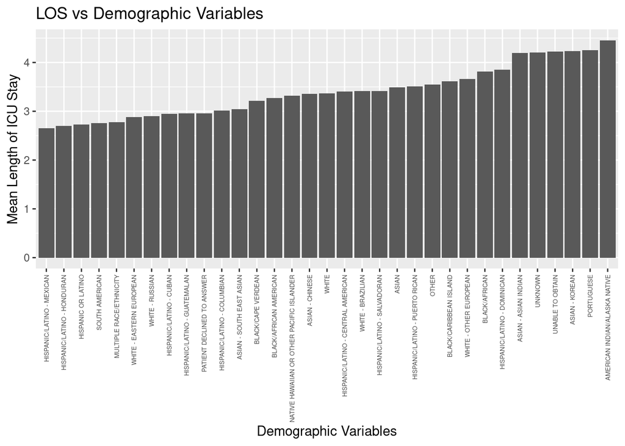

```r
# Visualize the results
# Mean length of ICU stay `los` vs ethnicity groups
# I sorted the mean length of ICU Stay of groups in ascending order.
ggplot(race_summary, aes(x = reorder(race, + mean_los_race),
                         y = mean_los_race)) +
  geom_bar(stat = "identity", position = "dodge") +
  labs(title = "LOS vs Demographic Variables",
       x = "Demographic Variables",
       y = "Mean Length of ICU Stay") +
  theme(axis.text.x = element_text(size=5, angle = 90, vjust = 0.5, hjust=1))
```

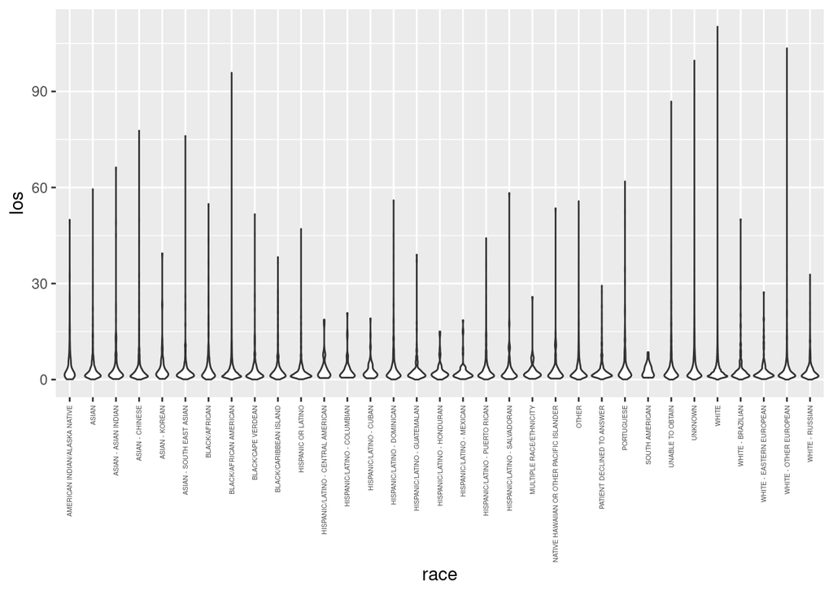

```r
# Box plot of length of ICU vs race
mimic_icu_cohort %>%
  ggplot(aes(x = race, y = los)) +
  geom_violin() +
  theme(axis.text.x = element_text(size=4, angle = 90, vjust = 0.5, hjust=1))
```

```r
# Numerical summary of length of ICU stay by insurance
insurance_summary <- mimic_icu_cohort %>%
  group_by(insurance) %>%
  summarize(
    mean_los_insurance = mean(los, na.rm = TRUE),
    median_los_insurance = median(los, na.rm = TRUE),
    min_los_insurance = min(los, na.rm = TRUE),
    max_los_insurance = max(los, na.rm = TRUE),
    sd_los_insurance = sd(los, na.rm = TRUE),
    count = n()
  )
insurance_summary
```

```
# A tibble: 3 × 7
  insurance mean_los_insurance median_los_insurance min_los_insurance
  <chr>                  <dbl>                <dbl>             <dbl>
1 Medicaid                3.46                 1.81           0.00625
2 Medicare                3.48                 2.01           0.00145
3 Other                   3.42                 1.87           0.00125
# ℹ 3 more variables: max_los_insurance <dbl>, sd_los_insurance <dbl>,
#   count <int>
```

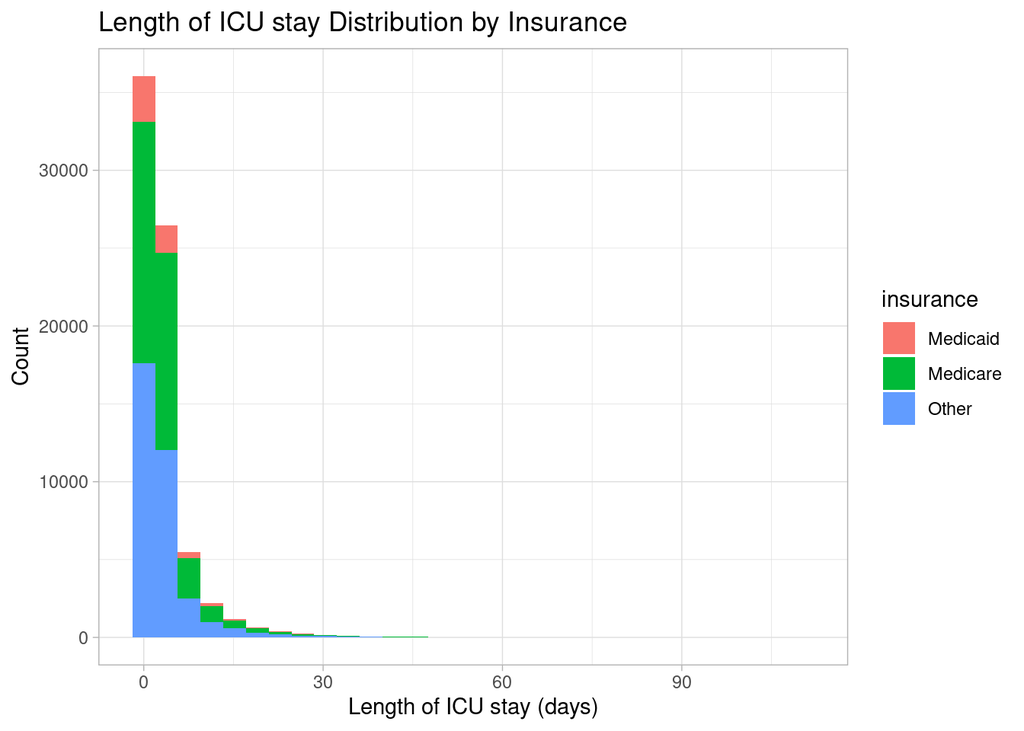

```r
mimic_icu_cohort |>
  ggplot(aes(x = los, fill = insurance)) +
  geom_histogram(bins = 30) +
  labs(title = "Length of ICU stay Distribution by Insurance",
       x = "Length of ICU stay (days)",
       y = "Count") +
  theme_light()
```

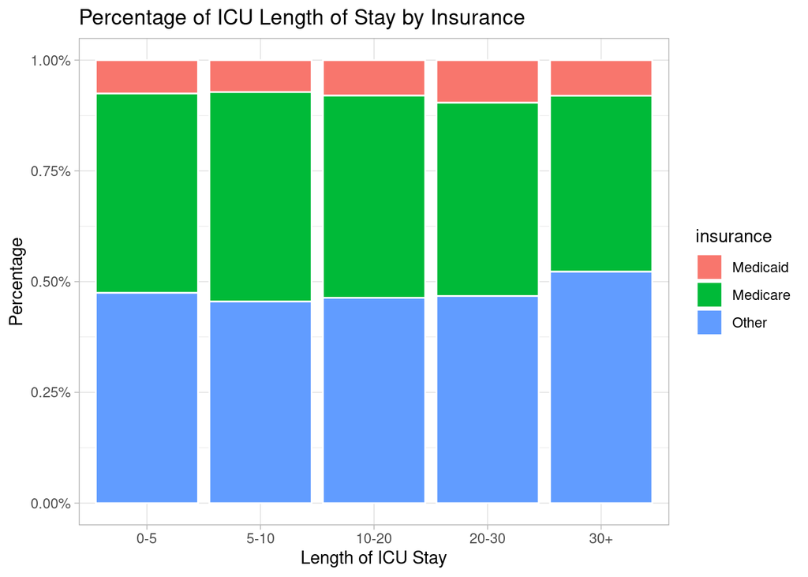

```r
# Since the distribution length of ICU stay is right-skewed,
# I grouped the length of ICU stay into 5 groups and plot a percentage plot,
#which will make the plot more readable.

mimic_icu_cohort <- mimic_icu_cohort %>%
  mutate(los_grouped = cut(los, breaks = c(0, 5, 10, 20, 30, Inf),
                           labels = c("0-5", "5-10", "10-20", "20-30", "30+")))

mimic_icu_cohort %>%
  ggplot(aes(x = los_grouped, fill = insurance)) +
  geom_bar(position = "fill", color = "white") +
  labs(title = "Percentage of ICU Length of Stay by Insurance",
       x = "Length of ICU Stay",
       y = "Percentage") +
  # Format y-axis as percentage
  scale_y_continuous(labels = scales::percent_format(scale = 1)) +
  theme_light()
```

- Length of ICU stay `los` vs marital status

```r
# Numerical summary of length of ICU stay by marital status
marital_status_summary <- mimic_icu_cohort %>%
  group_by(marital_status) %>%
  summarize(
    mean_los_marital_status = mean(los, na.rm = TRUE),
    median_los_marital_status = median(los, na.rm = TRUE),
    min_los_marital_status = min(los, na.rm = TRUE),
    max_los_marital_status = max(los, na.rm = TRUE),
    sd_los_marital_status = sd(los, na.rm = TRUE),
    count = n()
  )
marital_status_summary
```

```
# A tibble: 5 × 7
  marital_status mean_los_marital_status median_los_marital_status
  <chr>                            <dbl>                     <dbl>
1 DIVORCED                          3.39                      1.90
2 MARRIED                           3.46                      1.94
3 SINGLE                            3.40                      1.87
4 WIDOWED                           3.13                      1.93
5 <NA>                              4.28                      2.20
# ℹ 4 more variables: min_los_marital_status <dbl>,
#   max_los_marital_status <dbl>, sd_los_marital_status <dbl>, count <int>
```

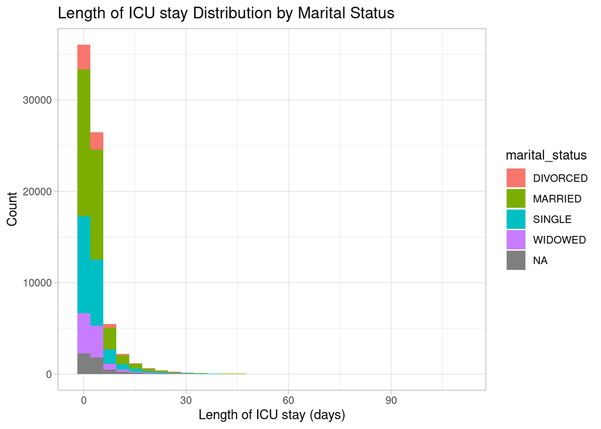

```r
# Histogram plot of length of ICU stay distribution by marital status
mimic_icu_cohort |>
  ggplot(aes(x = los, fill = marital_status)) +
  geom_histogram(bins = 30) +
  labs(title = "Length of ICU stay Distribution by Marital Status",
       x = "Length of ICU stay (days)",
       y = "Count") +
  theme_light()
```

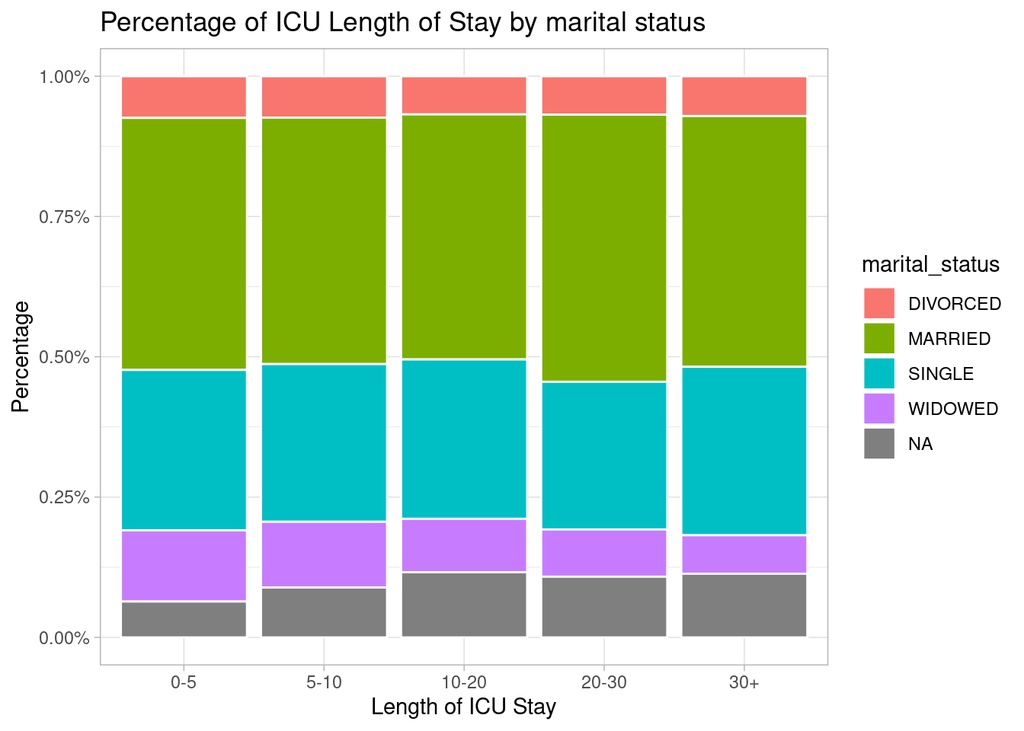

```r
# Percentage plot of length of ICU stay by marital status
mimic_icu_cohort %>%
  ggplot(aes(x = los_grouped, fill = marital_status)) +
  geom_bar(position = "fill", color = "white") +
  labs(title = "Percentage of ICU Length of Stay by marital status",
       x = "Length of ICU Stay",
       y = "Percentage") +
  scale_y_continuous(labels = scales::percent_format(scale = 1)) +
  theme_light()
```

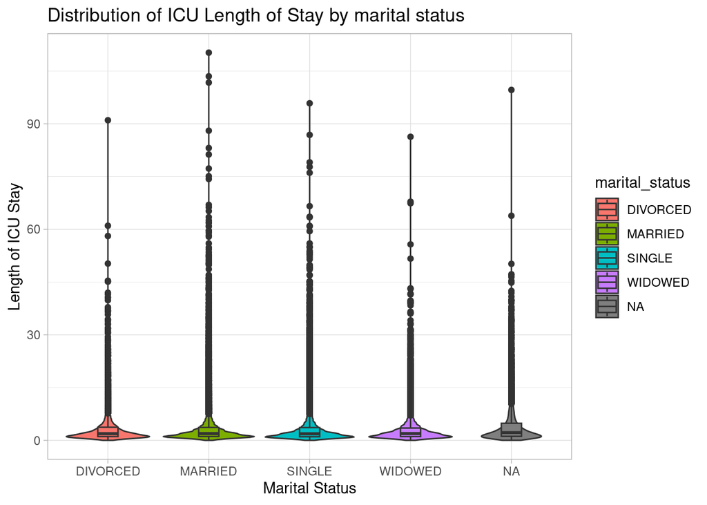

```r
# Violin plot of length of ICU stay by marital status
mimic_icu_cohort %>%
  ggplot(aes(x = marital_status, y = los, fill = marital_status)) +
  geom_violin() +
  geom_boxplot(width = 0.2) +
  labs(title = "Distribution of ICU Length of Stay by marital status",
       x = "Marital Status",
       y = "Length of ICU Stay") +
  guides(color = "none") +
  theme_light()
```

- Length of ICU stay `los` vs gender

```r
# Numerical summary of length of ICU stay by gender
gender_summary <- mimic_icu_cohort |>
  group_by(gender)|>
  summarize(
    mean_los = mean(los, na.rm = TRUE),
    median_los = median(los, na.rm = TRUE),
    min_los = min(los, na.rm = TRUE),
    max_los = max(los, na.rm = TRUE),
    sd_los = sd(los, na.rm = TRUE),
    count = n()
  )
gender_summary
```

```
# A tibble: 2 × 7
  gender mean_los median_los min_los max_los sd_los count
  <chr>     <dbl>      <dbl>   <dbl>   <dbl>  <dbl> <int>
1 F          3.34       1.91 0.00145    110.   4.70 32363
2 M          3.54       1.94 0.00125    103.   5.09 40818
```

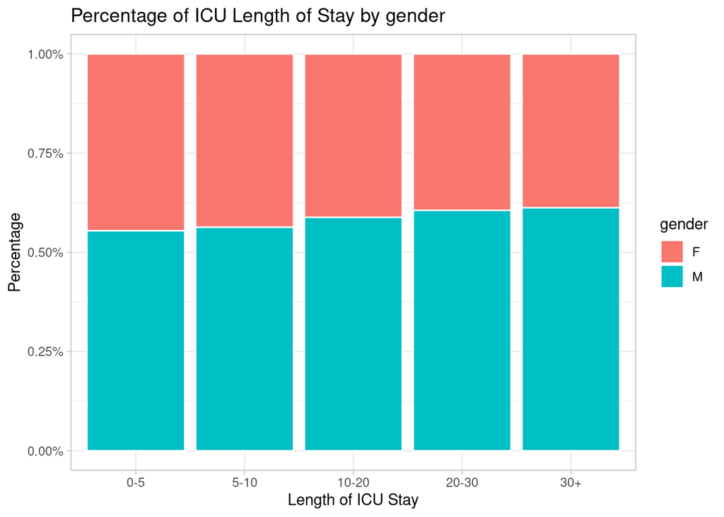

```r
# Percentage plot of length of ICU stay by gender
mimic_icu_cohort %>%
  ggplot(aes(x = los_grouped, fill = gender)) +
  geom_bar(position = "fill", color = "white") +
  labs(title = "Percentage of ICU Length of Stay by gender",
       x = "Length of ICU Stay",
       y = "Percentage") +
  scale_y_continuous(labels = scales::percent_format(scale = 1)) +
  theme_light()
```

- Length of ICU stay `los` vs age at intime

```r
# Fit a linear regression of length of ICU stay `los` vs age at intime
lm_los_age <- lm(los ~ age, data = mimic_icu_cohort)
summary(lm_los_age)
```

```
Call:
lm(formula = los ~ age, data = mimic_icu_cohort)

Residuals:
    Min      1Q  Median      3Q     Max
 -3.482  -2.369  -1.523   0.263 106.774

Coefficients:
             Estimate Std. Error t value Pr(>|t|)
(Intercept)  3.517610   0.072064  48.812   <2e-16 ***
age         -0.001015   0.001078  -0.942    0.346
---
Signif. codes:  0 '***' 0.001 '**' 0.01 '*' 0.05 '.' 0.1 ' ' 1

Residual standard error: 4.923 on 73179 degrees of freedom
Multiple R-squared:  1.212e-05, Adjusted R-squared:  -1.541e-06
F-statistic: 0.8872 on 1 and 73179 DF,  p-value: 0.3462
```

we did not find a significant relationship between length of ICU stay and age at intime.

```r
summary(mimic_icu_cohort$age)
```

```
   Min. 1st Qu.  Median    Mean 3rd Qu.    Max.
  18.00   54.00   66.00   64.68   77.00  102.00
```

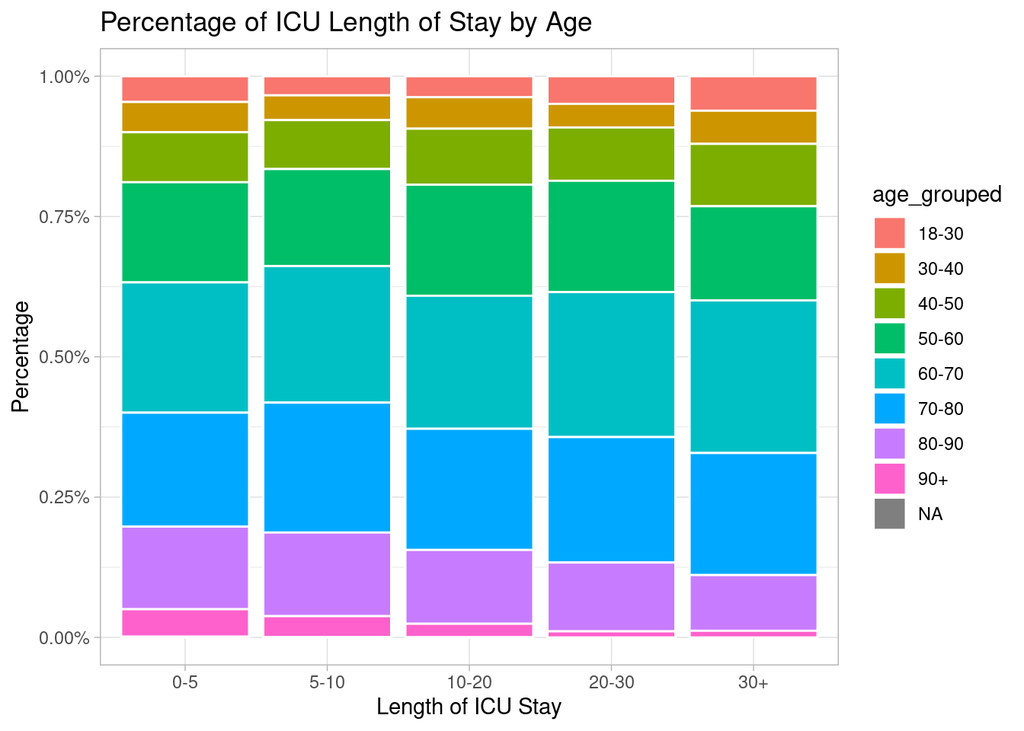

```r
mimic_icu_cohort <- mimic_icu_cohort %>%
  mutate(age_grouped = cut(age, breaks = c(18, 30, 40, 50, 60, 70, 80, 90, Inf),
                           labels = c("18-30", "30-40", "40-50", "50-60",
                           "60-70", "70-80", "80-90", "90+")))

# Percentage plot of length of ICU stay (grouped) by age of intime (grouped)
mimic_icu_cohort %>%
  ggplot(aes(x = los_grouped, fill = age_grouped)) +
  geom_bar(position = "fill", color = "white") +
  labs(title = "Percentage of ICU Length of Stay by Age",
       x = "Length of ICU Stay",
       y = "Percentage") +
  scale_y_continuous(labels = scales::percent_format(scale = 1)) +
  theme_light()
```

- Length of ICU stay `los` vs the last available lab measurements before ICU stay

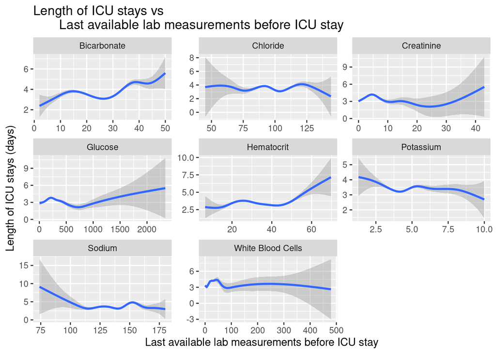

```r
library(dplyr)
library(ggplot2)
library(tidyr)

# Reshape the data using gather
mimic_icu_cohort_long <- mimic_icu_cohort %>%
  gather(key = "lab_variable", value = "lab_value", 28:35)

# Plot los ~ last available lab measurements for multiple variables
mimic_icu_cohort_long |>
  ggplot(mapping = aes(x = lab_value, y = los)) +
  geom_smooth(method = 'gam', formula = y ~ s(x, bs = "cs")) +
  facet_wrap(~ lab_variable, scales = "free") +
  labs(title = "Length of ICU stays vs
       Last available lab measurements before ICU stay",
       x = "Last available lab measurements before ICU stay",
       y = "Length of ICU stays (days)")
```

- Length of ICU stay `los` vs the first vital measurements within the ICU stay

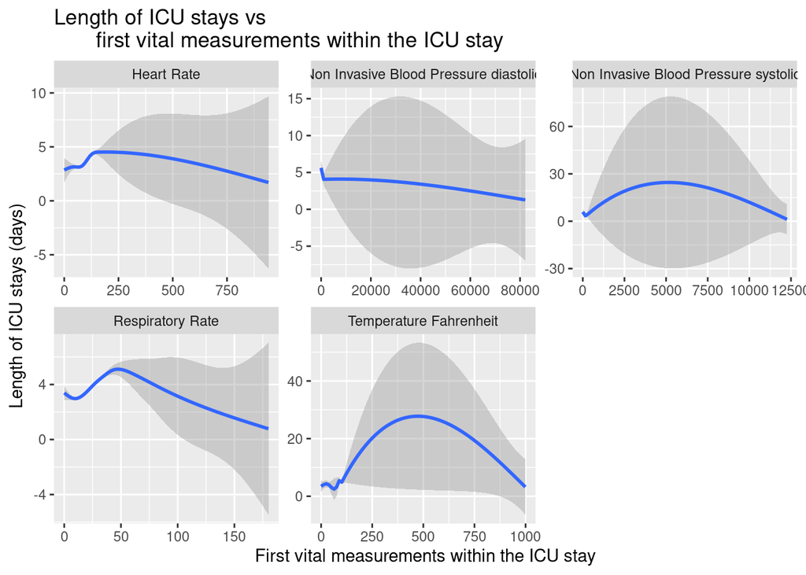

```r
# Reshape the data using gather
mimic_icu_cohort_long_2 <- mimic_icu_cohort %>%
  gather(key = "vital_variable", value = "vital_value", 36:40)

# Plot los ~ last available lab measurements for multiple variables
mimic_icu_cohort_long_2 |>
  ggplot(mapping = aes(x = vital_value, y = los)) +
  geom_smooth(method = 'gam', formula = y ~ s(x, bs = "cs")) +
  facet_wrap(~ vital_variable, scales = "free") +
  labs(title = "Length of ICU stays vs
       first vital measurements within the ICU stay",
       x = "First vital measurements within the ICU stay",
       y = "Length of ICU stays (days)")
```

- Length of ICU stay `los` vs first ICU unit

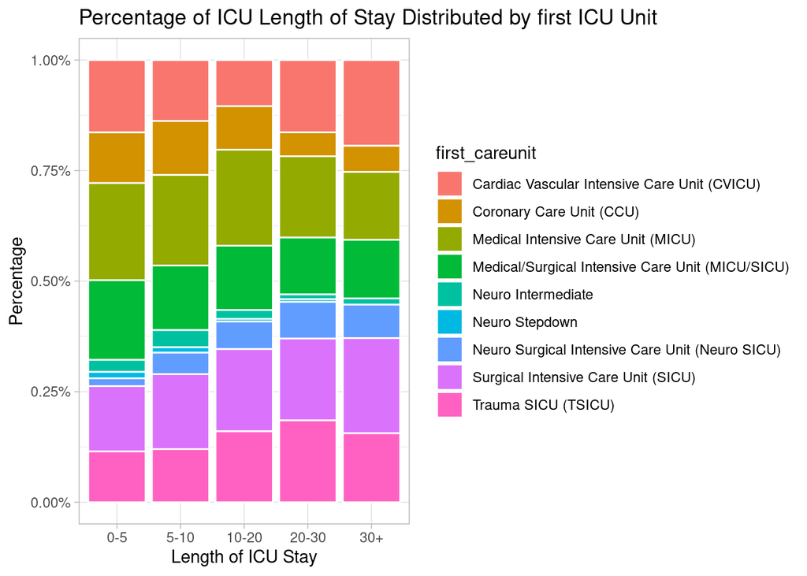

```r
# Percentage plot of length of ICU stay by first ICU Unit
mimic_icu_cohort %>%
  ggplot(aes(x = los_grouped, fill = first_careunit)) +
  geom_bar(position = "fill", color = "white") +
  labs(title = "Percentage of ICU Length of Stay Distributed by first ICU Unit",
       x = "Length of ICU Stay",
       y = "Percentage") +
  scale_y_continuous(labels = scales::percent_format(scale = 1)) +
  theme_light()
```